# Comment of removing the effect of `eta`

Raju Rimal

4/16/2019

```r
get_cov <- function(obj, type = c("y", "x"), digits = 3) {
  ny <- obj$m
  sigma <- obj$Sigma
  out <- switch(
    type,
    y = sigma[1:ny, 1:ny],
    x = sigma[-c(1:ny), -c(1:ny)])
  rownames(out) <- paste0(toupper(type), 1:nrow(out))
  colnames(out) <- paste0(toupper(type), 1:ncol(out))
  return(round(out, digits = digits))
}
```

```r
corcov <- lapply(unique(design$eta), function(e){
  sobj <- design %>%
    filter(eta == e) %>%
    get_design(1) %>%
    simulate()
  covs <- list(
    population = get_cov(sobj, "y"),
    sample = cov(sobj$Y)
  )
  cors <- lapply(covs, cov2cor)
  return(list(cov = covs, cor = cors))
})
names(corcov) <- glue::glue("eta:{unique(design$eta)}")
```

# Response and Response Components

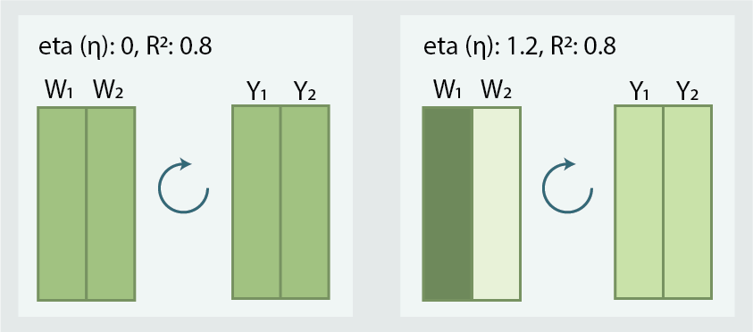

Here, the information content in the response components is same and when rotated they spread out to different response variables. In the case of high `eta` due to large amount of noisy content in uninformative response the response variables after rotation gets less informative which if modelled alone performes poor and that is what happening with PCR and PLS1 methods. On the other hand, `eta=0` distributes the information in all response components which when rotated will also distribute the same information in all response variables. This will give responses with richer information and low noise which will also be favorable if modelled alone as in the case of PCR and PLS1.

# Estimation Error Plot

Here if we scale away the effect of `eta` there is no point in including `eta` in the design. This will reduce our 32 design to just 8 designs. Further the head-to-head comparison with prediction paper will not be possible. In case you might be wondering how the covariance and correlation structure looks like in these different `eta` cases, I have included both sample and population version of them in the following section.

## Before Scaling

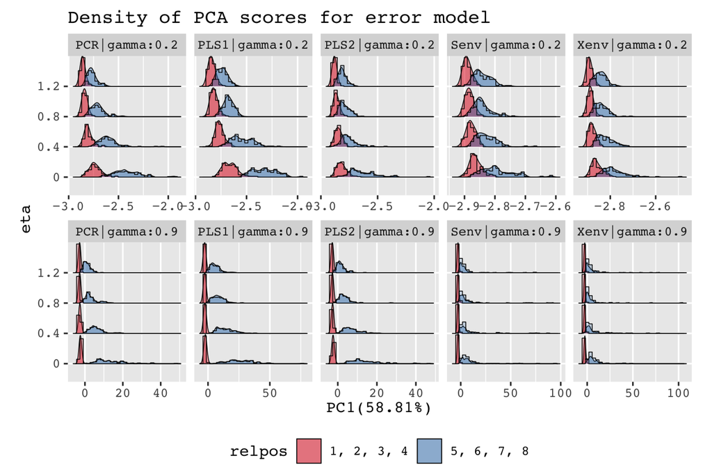

## After Scaling

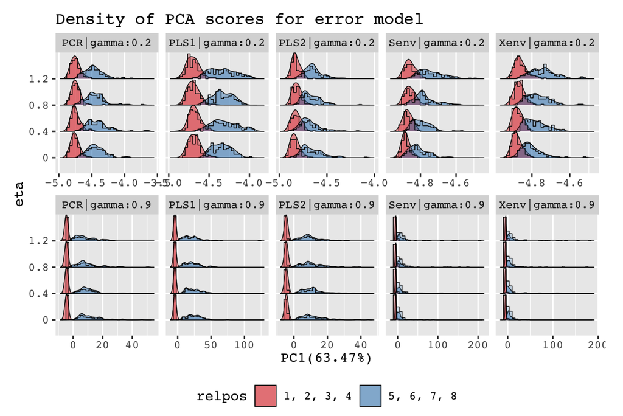

# Structure in Response

## Covariance Structures

### Population

```r
corcov %>%
  map_depth(2, "population") %>%
  map("cov") %>%
  map(round, 3)
```

```
$`eta:0`
   Y1 Y2 Y3 Y4
Y1  1  0  0  0
Y2  0  1  0  0
Y3  0  0  1  0
Y4  0  0  0  1

$`eta:0.8`
       Y1     Y2     Y3     Y4
Y1  0.521 -0.324 -0.001 -0.105
Y2 -0.324  0.667 -0.259  0.007
Y3 -0.001 -0.259  0.358 -0.007
Y4 -0.105  0.007 -0.007  0.195

$`eta:0.4`
       Y1     Y2     Y3     Y4
Y1  0.532 -0.085 -0.196  0.051
Y2 -0.085  0.588 -0.149 -0.053
Y3 -0.196 -0.149  0.822 -0.175
Y4  0.051 -0.053 -0.175  0.479

$`eta:1.2`
       Y1     Y2     Y3     Y4
Y1  0.311 -0.264  0.074 -0.094
Y2 -0.264  0.696 -0.353 -0.052
Y3  0.074 -0.353  0.272  0.034
Y4 -0.094 -0.052  0.034  0.140
```

### Sample

```r
corcov %>%
  map_depth(2, "sample") %>%
  map("cov") %>%
  map(round, 3)
```

```
$`eta:0`
       Y1     Y2     Y3     Y4
Y1  1.060 -0.008  0.025 -0.077
Y2 -0.008  0.888  0.087  0.045
Y3  0.025  0.087  1.003 -0.134
Y4 -0.077  0.045 -0.134  0.950

$`eta:0.8`
       Y1     Y2     Y3     Y4
Y1  0.467 -0.306  0.061 -0.071
Y2 -0.306  0.566 -0.201  0.001
Y3  0.061 -0.201  0.264  0.000
Y4 -0.071  0.001  0.000  0.181

$`eta:0.4`
       Y1     Y2     Y3     Y4
Y1  0.538  0.013 -0.348  0.086
Y2  0.013  0.778 -0.181 -0.083
Y3 -0.348 -0.181  0.741 -0.130
Y4  0.086 -0.083 -0.130  0.392

$`eta:1.2`
       Y1     Y2     Y3     Y4
Y1  0.236 -0.165  0.040 -0.087
Y2 -0.165  0.602 -0.336 -0.046
Y3  0.040 -0.336  0.275  0.026
Y4 -0.087 -0.046  0.026  0.123
```

## Correlation Structures

### Population

```r
corcov %>%
  map_depth(2, "population") %>%
  map("cor") %>%
  map(round, 3)
```

```
$`eta:0`
   Y1 Y2 Y3 Y4
Y1  1  0  0  0
Y2  0  1  0  0
Y3  0  0  1  0
Y4  0  0  0  1

$`eta:0.8`
       Y1     Y2     Y3     Y4
Y1  1.000 -0.550 -0.002 -0.329
Y2 -0.550  1.000 -0.530  0.019
Y3 -0.002 -0.530  1.000 -0.026
Y4 -0.329  0.019 -0.026  1.000

$`eta:0.4`
       Y1     Y2     Y3     Y4
Y1  1.000 -0.152 -0.296  0.101
Y2 -0.152  1.000 -0.214 -0.100
Y3 -0.296 -0.214  1.000 -0.279
Y4  0.101 -0.100 -0.279  1.000

$`eta:1.2`
       Y1     Y2     Y3     Y4
Y1  1.000 -0.567  0.254 -0.450
Y2 -0.567  1.000 -0.811 -0.167
Y3  0.254 -0.811  1.000  0.174
Y4 -0.450 -0.167  0.174  1.000
```

### Sample

```r
corcov %>%
  map_depth(2, "sample") %>%
  map("cor") %>%
  map(round, 3)
```

```
$`eta:0`
       Y1     Y2     Y3     Y4
Y1  1.000 -0.008  0.024 -0.076
Y2 -0.008  1.000  0.093  0.049
Y3  0.024  0.093  1.000 -0.138
Y4 -0.076  0.049 -0.138  1.000

$`eta:0.8`
       Y1     Y2     Y3     Y4
Y1  1.000 -0.595  0.175 -0.244
Y2 -0.595  1.000 -0.520  0.005
Y3  0.175 -0.520  1.000  0.002
Y4 -0.244  0.005  0.002  1.000

$`eta:0.4`
       Y1     Y2     Y3     Y4
Y1  1.000  0.020 -0.551  0.187
Y2  0.020  1.000 -0.239 -0.151
Y3 -0.551 -0.239  1.000 -0.240
Y4  0.187 -0.151 -0.240  1.000

$`eta:1.2`
       Y1     Y2     Y3    Y4
Y1  1.000 -0.438  0.157 -0.51
Y2 -0.438  1.000 -0.827 -0.17
Y3  0.157 -0.827  1.000  0.14
Y4 -0.510 -0.170  0.140  1.00
```

# Our design

```r
design_chr %>%
  rownames_to_column("Design") %>%
  DT::datatable(rownames = FALSE,
                options = list(dom="tp")) %>%
  DT::formatStyle(c("Design", names(design_chr)),
                  fontFamily = "monospace")
```

| Design | n | p | m | relpos | eta | gamma | R2 | ypos | q | type |
| --- | --- | --- | --- | --- | --- | --- | --- | --- | --- | --- |
| 1 | 100 | 20 | 4 | 1, 2, 3, 4 | 0 | 0.2 | 0.8 | 1, 2, 3, 4 | 20 | multivariate |
| 2 | 100 | 20 | 4 | 1, 2, 3, 4 | 0.8 | 0.9 | 0.8 | 1, 2, 3, 4 | 20 | multivariate |
| 3 | 100 | 250 | 4 | 1, 2, 3, 4 | 0.8 | 0.9 | 0.8 | 1, 2, 3, 4 | 250 | multivariate |
| 4 | 100 | 250 | 4 | 1, 2, 3, 4 | 0 | 0.2 | 0.8 | 1, 2, 3, 4 | 250 | multivariate |
| 5 | 100 | 20 | 4 | 1, 2, 3, 4 | 0.8 | 0.2 | 0.8 | 1, 2, 3, 4 | 20 | multivariate |
| 6 | 100 | 20 | 4 | 1, 2, 3, 4 | 0 | 0.9 | 0.8 | 1, 2, 3, 4 | 20 | multivariate |
| 7 | 100 | 250 | 4 | 1, 2, 3, 4 | 0 | 0.9 | 0.8 | 1, 2, 3, 4 | 250 | multivariate |
| 8 | 100 | 250 | 4 | 1, 2, 3, 4 | 0.8 | 0.2 | 0.8 | 1, 2, 3, 4 | 250 | multivariate |
| 9 | 100 | 20 | 4 | 5, 6, 7, 8 | 0 | 0.9 | 0.8 | 1, 2, 3, 4 | 20 | multivariate |
| 10 | 100 | 20 | 4 | 5, 6, 7, 8 | 0.8 | 0.2 | 0.8 | 1, 2, 3, 4 | 20 | multivariate |

[output cut: 22 more lines]